# AD Neural Network

Patrick Lang

3/5/2021

# AD Classification Neural Network in Base R

The following code shows how to create a neural network and train it. The NN that will be created has 3 layers:

- Input Layer - 8 units (8 covariates included in training)
- Hidden Layer - 64 units (arbitrarily chosen, can be tweaked)
- Output Layer - 2 units (represents the output classes, improved or declined)

```r
#importing data
train <- read.csv("../Data/gainn_final.csv")
```

```r
#Viewing Data
summary(train)
```

```
##        ID            AGE            SEX                RACE
##  Min.   :   1   Min.   : 45.0   Length:42065       Length:42065
##  1st Qu.:2532   1st Qu.: 68.0   Class :character   Class :character
##  Median :5011   Median : 75.0   Mode  :character   Mode  :character
##  Mean   :5012   Mean   : 86.3
##  3rd Qu.:7502   3rd Qu.: 80.0
##  Max.   :9999   Max.   :999.0
##
##     ETHNIC            COUNTRY           DIAGNOSIS            VISITNUM
##  Length:42065       Length:42065       Length:42065       Min.   :   -4.0
##  Class :character   Class :character   Class :character   1st Qu.:    3.0
##  Mode  :character   Mode  :character   Mode  :character   Median :    7.0
##                                                           Mean   :  141.6
##                                                           3rd Qu.:   18.0
##                                                           Max.   :10105.0
##
##     VISIT             STUDY_DAY      PREDICTOR_A_T1  PREDICTOR_A_T2
##  Length:42065       Min.   :-239.0   Min.   :2.000   Min.   :2.000
##  Class :character   1st Qu.:   1.0   1st Qu.:3.000   1st Qu.:3.000
##  Mode  :character   Median : 114.0   Median :3.000   Median :3.000
##                     Mean   : 183.2   Mean   :3.154   Mean   :3.483
##                     3rd Qu.: 295.0   3rd Qu.:3.000   3rd Qu.:4.000
##                     Max.   :1170.0   Max.   :4.000   Max.   :4.000
##                     NA's   :1854     NA's   :25222   NA's   :25222
##    M1_ITEM1         M1_ITEM1_S1          M1_ITEM2           M1_ITEM3
##  Length:42065       Length:42065       Length:42065       Length:42065
##  Class :character   Class :character   Class :character   Class :character
##  Mode  :character   Mode  :character   Mode  :character   Mode  :character
##
##
##
##
##    M1_ITEM4           M1_ITEM5           M1_ITEM6           M1_ITEM7
##  Length:42065       Length:42065       Length:42065       Length:42065
##  Class :character   Class :character   Class :character   Class :character
##  Mode  :character   Mode  :character   Mode  :character   Mode  :character
##
##
##
##
```

[output cut: 33 more lines]

```
##  Length:42065       Length:42065       Length:42065       Length:42065
##  Class :character   Class :character   Class :character   Class :character
##  Mode  :character   Mode  :character   Mode  :character   Mode  :character
##
##
##
##
##   M2_ITEM11         M2_ITEM11_S1       M2_ITEM11_S2       M2_ITEM11_S3
##  Length:42065       Length:42065       Length:42065       Length:42065
##  Class :character   Class :character   Class :character   Class :character
##  Mode  :character   Mode  :character   Mode  :character   Mode  :character
##
##
##
##
```

## Data Preprocessing

Data Preprocessing Steps

- Select Relevant Variables
- Assign Correct Variable Types
- Derive Dependent Variable (ADAS-COG 11)
- Remove Rows w/ Missing DV
- Calculate New Timing Variable
- Select Baseline and 3 Month Visits
- Pivot Data Wider, Creating One Row per Subject
- Remove Patients w/o BL & 3 Month Visits
- Create Binary Variables from Categorical Variables
- Normalize Continuous Variables
- Derive New DV
- Split X and y
- Transform X into expected shape *(n_cov, n_patients)*
- One-hot Encode y from *(n_patients, 1)* to a *(n_classes, n_patients)* matrix

```r
#Data Visualization
summary(train2)
```

```
##        ID            AGE             SEX                RACE
##  Min.   :   1   Min.   : 45.00   Length:31467       Length:31467
##  1st Qu.:2534   1st Qu.: 68.00   Class :character   Class :character
##  Median :5040   Median : 75.00   Mode  :character   Mode  :character
##  Mean   :5024   Mean   : 80.51
##  3rd Qu.:7510   3rd Qu.: 80.00
##  Max.   :9999   Max.   :999.00
##     ETHNIC            COUNTRY           DIAGNOSIS            VISITNUM
##  Length:31467       Length:31467       Length:31467       Min.   :   -1.0
##  Class :character   Class :character   Class :character   1st Qu.:    5.0
##  Mode  :character   Mode  :character   Mode  :character   Median :    8.0
##                                                           Mean   :  185.2
##                                                           3rd Qu.:   20.0
##                                                           Max.   :10105.0
##    STUDY_DAY          DV          delta_time     time_since_first_visit
##  Min.   :-180   Min.   : 0.00   Min.   :  0.00   Min.   :   0.0
##  1st Qu.:  43   1st Qu.:15.00   1st Qu.: 30.00   1st Qu.:  55.0
##  Median : 169   Median :21.70   Median : 70.00   Median : 176.0
##  Mean   : 213   Mean   :23.51   Mean   : 60.62   Mean   : 222.7
##  3rd Qu.: 358   3rd Qu.:30.00   3rd Qu.: 91.00   3rd Qu.: 364.0
##  Max.   :1170   Max.   :75.00   Max.   :547.00   Max.   :1169.0
```

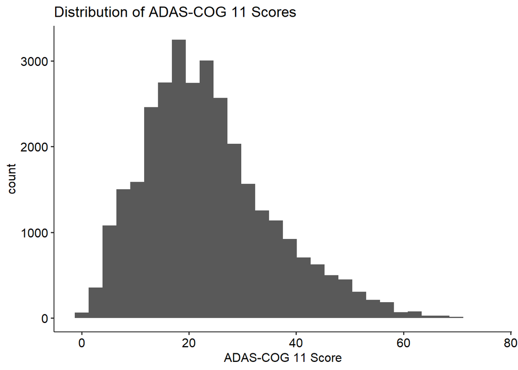

```r
ggplot(train2, aes(x = DV)) +
  geom_histogram() +
  theme_pubr() +
  xlab("ADAS-COG 11 Score") +
  ggtitle("Distribution of ADAS-COG 11 Scores")
```

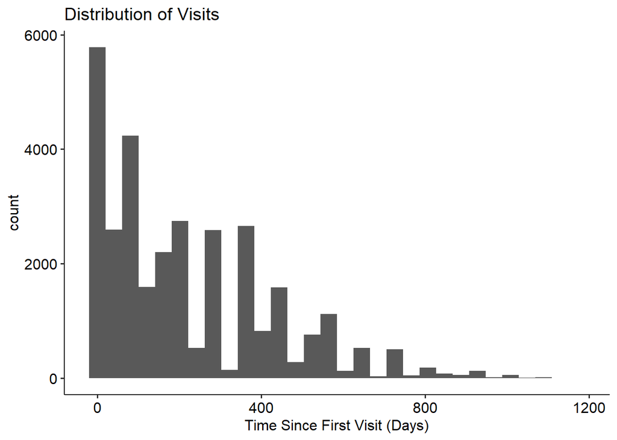

```r
ggsave("../Figures/dv_dist.png", width = 16, height = 9, units = "cm")
ggplot(train2, aes(x = time_since_first_visit)) +
  geom_histogram() +
  theme_pubr() +
  xlab("Time Since First Visit (Days)") +
  ggtitle("Distribution of Visits")
```

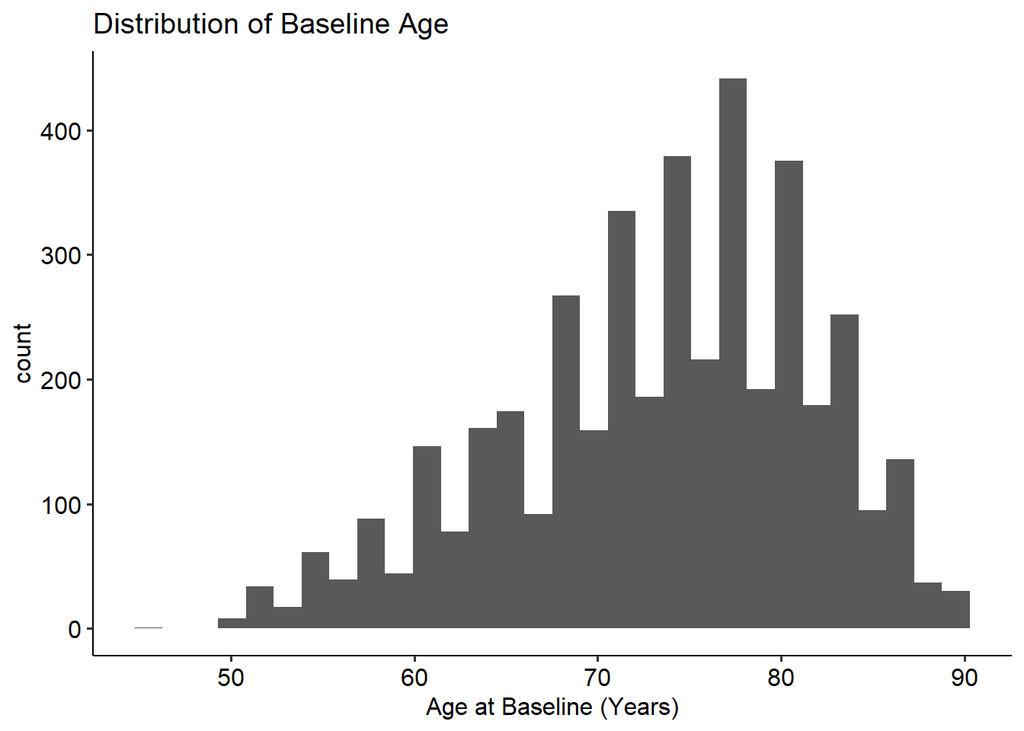

```r
ggsave("../Figures/time_dist.png", width = 16, height = 9, units = "cm")
#Data Curation
train3 <- train2 %>%
  select(-VISITNUM) %>%
  filter(time_since_first_visit == 0 | between(time_since_first_visit, 77, 105)) %>%
  mutate(time = case_when(time_since_first_visit == 0 ~ "baseline",
                          TRUE ~ "month3")) %>%
  distinct(ID, time, .keep_all = TRUE) %>%
  select(ID, AGE, SEX, RACE, ETHNIC, DIAGNOSIS, time, DV) %>%
  pivot_wider(names_from=time, values_from=DV) %>%
  filter(!is.na(baseline) & !is.na(month3)) %>%
  ungroup() %>%
  mutate(SEX = case_when(SEX == "F" ~ 0,
                         TRUE ~ 1),
         RACE = case_when(RACE == "WHITE" ~ 0,
                          TRUE ~ 1),
         ETHNIC = case_when(ETHNIC == "HISPANIC OR LATINO" ~ 1,
                            TRUE ~ 0),
         AD = case_when(DIAGNOSIS == "ALZHEIMER'S DISEASE" ~ 1,
                        TRUE ~ 0),
         MILDAD = case_when(DIAGNOSIS == "MILD TO MODERATE ALZHEIMER'S DISEASE" ~ 1,
                            TRUE ~ 0),
         MCI = case_when(DIAGNOSIS == "MILD COGNITIVE IMPAIRMENT" ~ 1,
                         TRUE ~ 0)) %>%
  select(AGE, SEX, RACE, ETHNIC, AD, MILDAD, MCI, baseline, month3) %>%
  filter(AGE != 999) %>%
  mutate(AGE = AGE/max(AGE),
         baseline = baseline/70,
         month3 = month3/70) %>%
  rowwise() %>%
  mutate(perc_change = (month3 - baseline)/baseline,
         improved = case_when(perc_change <= 0 ~ 1,
                              TRUE ~ 0),
         declined = case_when(perc_change > 0 ~ 1,
                              TRUE ~ 0))

#Visualization of Final Covariates
ggplot(train3, aes(x = AGE*89)) +
  geom_histogram() +
  theme_pubr() +
  xlab("Age at Baseline (Years)") +
  ggtitle("Distribution of Baseline Age")
```

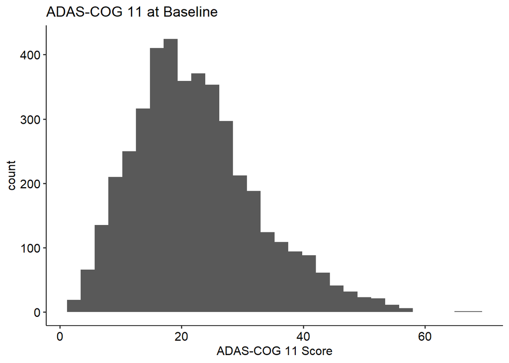

```r
ggsave("../Figures/age_dist.png", width = 16, height = 9, units = "cm")
ggplot(train3, aes(x = baseline*70)) +
  geom_histogram() +
  theme_pubr() +
  ggtitle("ADAS-COG 11 at Baseline") +
  xlab("ADAS-COG 11 Score")
```

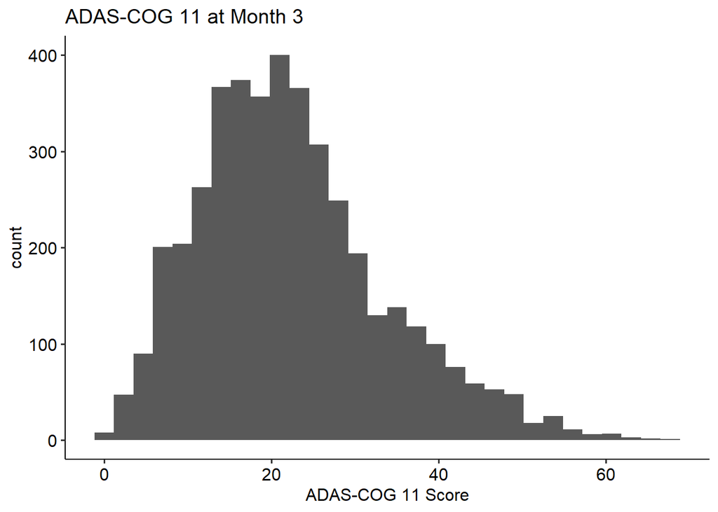

```r
ggsave("../Figures/baseline_dv_dist.png", width = 16, height = 9, units = "cm")
ggplot(train3, aes(x = month3*70)) +
  geom_histogram() +
  theme_pubr() +
  ggtitle("ADAS-COG 11 at Month 3") +
  xlab("ADAS-COG 11 Score")
```

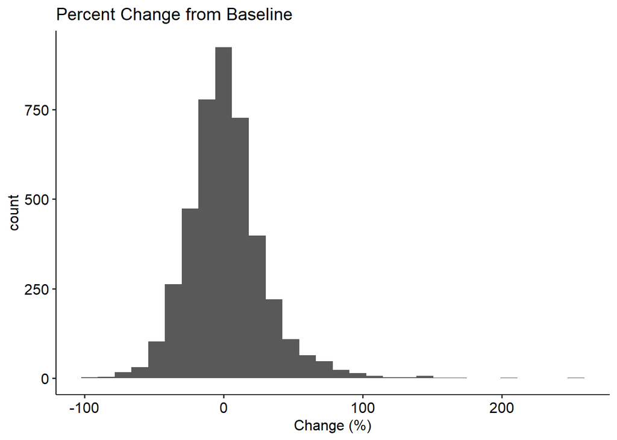

```r
ggsave("../Figures/month3_dv_dist.png", width = 16, height = 9, units = "cm")
ggplot(train3, aes(x = perc_change*100)) +
  geom_histogram() +
  theme_pubr() +
  ggtitle("Percent Change from Baseline") +
  xlab("Change (%)")
```

```r
ggsave("../Figures/month3_dv_dist.png", width = 16, height = 9, units = "cm")
sum_tab <- train3 %>%
  ungroup() %>%
  summarise(n_pat = n(),
            n_male = sum(SEX),
            n_non_white = sum(RACE),
            n_hispanic_or_latino = sum(ETHNIC),
            n_AD = sum(AD),
            n_MILDAD = sum(MILDAD),
            n_MCI = sum(MCI),
            n_improved = sum(improved),
            n_declined = sum(declined))

sum_tab
```

```
## # A tibble: 1 x 9
##   n_pat n_male n_non_white n_hispanic_or_l~  n_AD n_MILDAD n_MCI n_improved
##   <int>  <dbl>       <dbl>            <dbl> <dbl>    <dbl> <dbl>      <dbl>
## 1  4222   1895         302              132  3411      230   447       2215
## # ... with 1 more variable: n_declined <dbl>
```

```r
write_csv(sum_tab, "../Figures/summary_table.csv")


train <- train3 %>%
  select(-perc_change, -month3)
```

```r
train %<>%
  mutate(improved = as.factor(improved))

train_index <- createDataPartition(train$improved, p = 0.8, list = FALSE, times = 1)

train %<>%
  mutate(improved = as.numeric(as.character(improved)))

#reshaping X into shape (n_pixels, n_patients), it was previously (n_patients, n_pixels)
X <- t(as.matrix(train[train_index, ] %>% select(1:8)))
X_val <- t(as.matrix(train[-train_index, ] %>% select(1:8)))

#one hot encoding y as there are 10 possible classes (digits) and our output layer will contain 10 units, also reshaping to be (n_classes, n_patients)
y <- t(as.matrix(train[train_index, ] %>% select(9, 10)))

y_val <- t(as.matrix(train[-train_index, ] %>% select(9, 10)))
```

## Creating Functions to Build and Train the NN

This next section of code involves creating all of the necessary functions to build and train our neural network. They go as follows:

- Parameter initialization
- Forward propogation
  - Linear forward step
  - Activation functions (sigmoid and ReLU)
- Loss function
- Backward propogation
  - Linear backward step
  - Activation gradients (sigmoid and ReLU)
- Parameter updating

### Initializing Parameters

and creates the list *parameters* that contains:

- W1 — weight matrix of shape (n_h, n_x)
- b1 — bias vector of shape (n_h, 1)
- W2 — weight matrix of shape (n_y, n_h)
- b2 — bias vector of shape (n_y, 1)

```r
#creating function to initialize weights and biases of neural network
initialize_parameters <- function(n_x, n_h, n_y) {

  set.seed(123)

  #n_x - size of input layer (n_pixels)
  #n_h - size of hidden layer (n_units)
  #n_y - size of output layer (n_classes)

  #randomly initializing weight matrices using uniform distribution and bias vectors as zero vectors
  W1 <- matrix(runif(n_h * n_x), n_h, n_x)*.01
  b1 <- as.vector(rep(0, n_h))
  W2 <- matrix(runif(n_y * n_h), n_y, n_h)*.01
  b2 <- as.vector(rep(0, n_y))

  #W1 - weight matrix of shape (n_h, n_x)
  #b1 - bias vector of shape (n_h, 1)
  #W2 - weight matrix of shape (n_y, n_h)
  #b2 - bias vector of shape (n_y, 1)

  #combining parameters into a list
  parameters <- list("W1" = W1,
                     "b1" = b1,
                     "W2" = W2,
                     "b2" = b2)

  return(parameters)

}
```

### Linear Forward Propogation

This function takes inputs:

- A — activations from previous layer (or input data) of shape (size of previous layer, n_patients)
- W — weight matrix of shape (size of current layer, size of previous layer)
- b — bias vector of shape (size of current layer, 1)

and returns the list *Z_and_cache* which contains:

- Z — output of the linear function $Z^{[l]} = W^{[l]}*A^{[l-1]}+b^{[l]}$
- cache — a list containing the inputs, $A, W, b$ to make back propogation more efficient

```r
linear_fwd <- function(A, W, b) {

  #A -- input (activations) from previous layer (or input data): (size of previous layer, number of examples)
  #W -- weights matrix of shape (size of current layer, size of previous layer)
  #b -- bias vector of shape (size of the current layer, 1)

  #creating matrix Z of shape (size of previous layer, number of examples) (linear component of NN)
  Z <- matrix((W %*% A) + b, dim(W)[1], dim(A)[2])

  #saving cache to make back propogation more efficient
  cache <- list(A, W, b)

  #saving Z and cache into a list as R does not allow functions to return multiple variables
  Z_and_cache <- list("Z" = Z,
                 "cache" = cache)

  return(Z_and_cache)

}
```

### Sigmoid and ReLU Functions

These functions take input $Z$, perform a non-linear “activation” function, and return a list containing:

- A — the activation values
- cache — the input $Z$ stored to compute back propogation efficiently

The sigmoid function is $\sigma(Z) = \sigma(W A + b) = \frac{1}{ 1 + e^{-(W A + b)}}$

The Rectified Linear Unit (ReLU) function is $A = RELU(Z) = max(0, Z)$

```r
sigmoid <- function(Z) {

  #sigmoid function
  sig <- 1/(1+exp(-Z))

  #saving cache to make backpropogation more efficient
  sig_and_cache <- list("A" = sig,
                        "cache" = Z)

  return(sig_and_cache)

}

relu_func <- function(Z) {

  #rectified linear unit function
  relu <- pmax(Z, 0)

  #saving cache to make backpropogation more efficient
  relu_and_cache <- list("A" = relu,
                         "cache" = Z)

  return(relu_and_cache)

}
```

### Linear Activation Forward

This function combines the Linear Forward Propogation function and the activation functions (sigmoid and ReLU) and returns the list *A_and_cache* containing:

- A — output of the activation function
- linear_cache — cache from the linear forward step
- activation_cache — cache from the activation function

The equation to produce $A^{[l]}$ here is $A^{[l]} = g(Z^{[l]}) = g(W^{[l]}*A^{[l-1]}+b^{[l]})$ where $g$ is either the sigmoid or ReLU activation function.

```r
linear_activation_fwd <- function(A_prev, W, b, activation) {

  #applying linear and sigmoid/relu functions to activations
  if(activation == "sigmoid") {
    Z_and_cache <- linear_fwd(A_prev, W, b)
    A_and_cache <- sigmoid(Z_and_cache[["Z"]])
    } else if(activation == "relu") {
      Z_and_cache <- linear_fwd(A_prev, W, b)
      A_and_cache <- relu_func(Z_and_cache[["Z"]])
     }

  A_and_cache <- list("A" = A_and_cache[["A"]],
                      "linear_cache" = Z_and_cache[["cache"]],
                      "activation_cache" = A_and_cache[["cache"]])
}
```

### Cost Function

The cost function takes inputs:

- AL — probability matrix of label predictions of shape (n_classes, n_patients)
- Y — true label matrix of shape (n_classes, n_patients)

and returns the cross-entropy cost.

The cross-entropy cost $J$ is computed using the following formula:

$J = -\frac{1}{m} \sum\limits_{i = 1}^{m} (y^{(i)}\log\left(a^{[L] (i)}\right) + (1-y^{(i)})\log\left(1- a^{[L](i)}\right))$

```r
cost_func <- function(AL, Y) {

  #cost function
  m <- dim(Y)[2]
  logprobs <- (log(AL) * Y) + (log(1-AL) * (1-Y))
  cost <- -1/m*sum(logprobs)

  return(cost)

}
```

### Linear Backward Function

This function takes inputs:

- dZ — gradient of the cost with respect to the linear output of the current layer $dZ^{[l]} = \frac{\partial \mathcal{L} }{\partial Z^{[l]}}$
- A_and_cache — list containing *A_prev, W, b* from forward propogation in the current layer

computes the derivatives $dA^{[l]}, dW^{[l]}, db^{[l]}$ and returns the list *gradients* containing:

- dA_prev — gradient of the cost with respect to the activation of the previous layer with same shape as *A_prev*
- dW — gradient of the cost with respect to W of current layer with same shape as *W*
- db — gradient of the cost with respect to b of current layer with same shape as *b*

using the following formulas:

$dA^{[l-1]} = \frac{\partial \mathcal{L} }{\partial A^{[l-1]}} = W^{[l] T} dZ^{[l]}$  
$dW^{[l]} = \frac{\partial \mathcal{L} }{\partial W^{[l]}} = \frac{1}{m} dZ^{[l]} A^{[l-1] T}$  
$db^{[l]} = \frac{\partial \mathcal{L} }{\partial b^{[l]}} = \frac{1}{m} \sum\limits_{i = 1}^{m} dZ^{[l](i)}$

```r
linear_backward <- function(dZ, A_and_cache) {

  #extracting things from cache
  A_prev <- A_and_cache[[1]]
  W <- A_and_cache[[2]]
  b <- A_and_cache[[3]]
  m <- dim(A_prev)[2]

  #taking derivitives
  dW <- 1/m*(dZ %*% t(A_prev))
  db <- 1/m*sum(dZ)
  dA_prev <- t(W) %*% dZ

  #saving gradients
  gradients <- list("dA_prev" = dA_prev,
                    "dW" = dW,
                    "db" = db)

  return(gradients)

}
```

### Activation Derivatives

These functions compute the derivatives of the activation functions with inputs:

- dA — post-activation gradient for current layer
- cache — either linear or activation cache that was stored for backward propogation

to return *dZ*

The computation can be represented as $dZ^{[l]} = dA^{[l]} * g'(Z^{[l]})$ where $g(.)$ is the activation function

```r
sigmoid_backward <- function(dA, cache) {

  #sigmoid derivative
  Z <- cache
  s = 1/(1+exp(-Z))
  dZ = dA * s * (1-s)

  return(dZ)

}

relu_backward <- function(dA, cache) {

  #relu derivative
  Z <- cache
  dZ <- dA

  dZ[Z<=0] <- 0

  return(dZ)

}
```

### Linear Activation Backward

This function impliments back propogation for the linear->activation layer with inputs:

- dA — post-activation gradient for current layer
- A_and_cache — list containing linear_cache and activation_cache
- activation — which activation to use for this layer (“sigmoid” or “relu”)

and returns the list *gradients* containing:

- dA_prev — gradient of the cost with respect to the activation of the previous layer with same shape as *A_prev*
- dW — gradient of the cost with respect to W of current layer with same shape as *W*
- db — gradient of the cost with respect to b of current layer with same shape as *b*

```r
linear_activation_back <- function(dA, A_and_cache, activation) {

  #extracting caches
  linear_cache <- A_and_cache[["linear_cache"]]
  activation_cache <- A_and_cache[["activation_cache"]]

  #gradient descent
  if(activation == "relu") {

    dZ <- relu_backward(dA, activation_cache)
    gradients <- linear_backward(dZ, linear_cache)

  } else if(activation == "sigmoid") {

    dZ <- sigmoid_backward(dA, activation_cache)
    gradients <- linear_backward(dZ, linear_cache)

  }

  return(gradients)

}
```

### Updating the Parameters

This function updates the parameters of the model using gradient descent. It takes inputs:

- parameters — list of parameters *W1, b1, W2, b2*
- l1_gradients — gradients from first NN layer
- l2_gradients — gradients from second NN layer
- learning_rate — the $\alpha$ you wish to use

and returns the list *parameters* containing the updated parameters.

Gradient descent works using the following equations:

$W^{[l]} = W^{[l]} - \alpha \text{ } dW^{[l]}$  
$b^{[l]} = b^{[l]} - \alpha \text{ } db^{[l]}$

```r
update_parameters <- function(parameters, l1_gradients, l2_gradients, learning_rate) {

  #updating parameters using learning rate and gradients
  parameters[["W1"]] <- parameters[["W1"]] - (learning_rate * l1_gradients[[2]])
  parameters[["b1"]] <- parameters[["b1"]] - (learning_rate * l1_gradients[[3]])
  parameters[["W2"]] <- parameters[["W2"]] - (learning_rate * l2_gradients[[2]])
  parameters[["b2"]] <- parameters[["b2"]] - (learning_rate * l2_gradients[[3]])

  return(parameters)

}
```

### Two Layer Model Function

This function combines all previous functions into a NN function. The inputs are:

- X — baseline data from training set
- Y — label matrix from training set
- layers_dimensions — list containing *n_x, n_h, n_y*

and has the tunable parameters of:

- learning_rate — the learning rate or $\alpha$ you want to use
- num_iterations — number of iterations you want the model to run through while training
- print_cost — whether or not to print the cost after every 100 iterations

This returns the list *parameters* which contains the tuned parameters *W1, b1, W2, b2*

```r
#defining the constants
n_x <- 8
n_h <- 64
n_y <- 2

#saving constants to a list
layers_dimensions <- list("n_x" = n_x,
                          "n_h" = n_h,
                          "n_y" = n_y)

two_layer_model <- function(X, Y, layers_dimensions, learning_rate = .0075, num_iterations = 3000, print_cost = FALSE) {

  set.seed(123)
  m <- dim(X)[2]
  n_x <- layers_dimensions[["n_x"]]
  n_h <- layers_dimensions[["n_h"]]
  n_y <- layers_dimensions[["n_y"]]

  parameters <- initialize_parameters(n_x, n_h, n_y)

  W1 <- parameters[["W1"]]
  b1 <- parameters[["b1"]]
  W2 <- parameters[["W2"]]
  b2 <- parameters[["b2"]]

  for(i in 1:num_iterations) {

    A1_and_cache <- linear_activation_fwd(X, W1, b1, activation = "relu")
    A2_and_cache <- linear_activation_fwd(A1_and_cache[["A"]], W2, b2, activation = "sigmoid")

    cost <- cost_func(A2_and_cache[["A"]], Y)

    dA2 <- -((Y/A2_and_cache[["A"]]) - ((1-Y)/(1-A2_and_cache[["A"]])))

    gradients2 <- linear_activation_back(dA2, A2_and_cache, activation = "sigmoid")
    gradients1 <- linear_activation_back(gradients2[[1]], A1_and_cache, activation = "relu")

    parameters <- update_parameters(parameters, gradients1, gradients2, learning_rate)

    W1 <- parameters[["W1"]]
    b1 <- parameters[["b1"]]
    W2 <- parameters[["W2"]]
    b2 <- parameters[["b2"]]

    if(print_cost == TRUE & i%%100 == 0) {
      print(cost)
    }


  }
  return(parameters)
}
```

## Running the Model

```r
parameters <- two_layer_model(X, y, layers_dimensions, .0075, 5000, TRUE)
```

```
## [1] 1.386275
## [1] 1.38626
## [1] 1.386242
## [1] 1.386217
## [1] 1.386182
## [1] 1.386132
## [1] 1.386061
## [1] 1.385961
## [1] 1.385825
## [1] 1.385645
## [1] 1.385419
## [1] 1.385154
## [1] 1.384867
## [1] 1.384587
## [1] 1.384343
```

[output cut: 35 more lines]

## Testing the NN

and returns the prediction and the true label

```r
#function to show models prediction and the true label
predict <- function(X, y, parameters) {

  predictions <- matrix(nrow = ncol(X), ncol = 4)

  for(i in 1:ncol(X)) {
    patient <- matrix(X[,i], 8, 1)
    truevec <- matrix(y[,i], 2, 1)

    W1 <- parameters[["W1"]]
    b1 <- parameters[["b1"]]
    W2 <- parameters[["W2"]]
    b2 <- parameters[["b2"]]

    A1 <- linear_activation_fwd(patient, W1, b1, activation = "relu")
    A2 <- linear_activation_fwd(A1[["A"]], W2, b2, activation = "sigmoid")

    predvec <- A2[["A"]]
    if(which(predvec == max(predvec)) == 1) {pred =  "patient improved"} else {pred = "patient declined"}
    if(which(truevec == max(truevec)) == 1) {true = "patient improved"} else {true = "patient declined"}
    acc <- ifelse(pred == true, "correctly", "incorrectly")

    predictions[i, 1] <- i
    predictions[i, 2] <- acc
    predictions[i, 3] <- pred
    predictions[i, 4] <- true

  }
  predictions <- as.tibble(predictions)
  names(predictions) <- c("patient", "accuracy", "predicted", "true")
  return(predictions)
}

preds <- predict(X_val, y_val, parameters)
```